# Differential Abundance Testing

James R. Walters & Katie McLaughlin

# Load Packages & Data

Load the necessary packages, the SE object, and the analysis scripts.

```r
suppressMessages(library(DEP))
```

```r
suppressMessages(library(SummarizedExperiment))
suppressMessages(library(Biostrings))
library(ggplot2)
library(kableExtra)
library(patchwork)

load("pieris_DEP_SE_object.RData")
```

# Filtering

## Remove Apyrene 4

Preliminary analysis indicated that there was something wrong with Apyrene 4. It appeared to be a notable outlier in terms of having few proteins detected and an apparently elevated distribution of abundances. So we will remove it from further analysis.

```r
pieris.se <- pieris.se[ , -which(colnames(pieris.se) == "Apyrene_4") ]
```

## Missing values filter

```r
pieris.logInt <- assay(pieris.se) # extract raw data of ion intensities into stand alone matrix
# get counts of non-NA observations across Apyrene and Eupyrene
Nobs.apy <- apply( pieris.logInt[, grep(pattern="Apy", x = colnames(pieris.logInt))],  1, function(x){sum(! is.na(x) )} )
Nobs.eup <- apply( pieris.logInt[, grep(pattern="Eup", x = colnames(pieris.logInt))],  1, function(x){sum(! is.na(x) )} )

# append these into SE object rowData
rowData(pieris.se)$Nobs.apy <- Nobs.apy
rowData(pieris.se)$Nobs.eup <- Nobs.eup

#Filter for proteins that are identified in replicates
pieris.filt <- filter_missval(pieris.se, thr = 2)
```

## PCA of filtered data

After removing “unexpressed” proteins, we can do a first-pass assessment of variation in the data via PCA. And do it up nice for inclusion in publication

```r
myCols <- c("goldenrod1", "orchid3")
pcaplot <- plot_pca(pieris.filt, n = 500) +
  scale_color_manual(values = myCols) +
  guides(shape=guide_legend(title="Replicate",
                            override.aes = list(size = 3)),
         color=guide_legend(title="Sperm morph"),
         ) +

  ggtitle("Principal Component Analysis")

# PDF version
ggsave(plot = pcaplot, filename = "../Results/PCA_filtered.pdf",
       width = 85, height = 80, units = "mm", scale = 1.7)
       #width = 5, height = 4, scale = 1.1)

# JPG version
ggsave(plot = pcaplot, filename = "../Results/PCA_filtered.jpg",
       width = 85, height = 80, units = "mm", scale = 1.7)
```

# Standard Visualizations

Generate standard `DEP` plots. Also, merge plots of overlap for a single plot in publication.

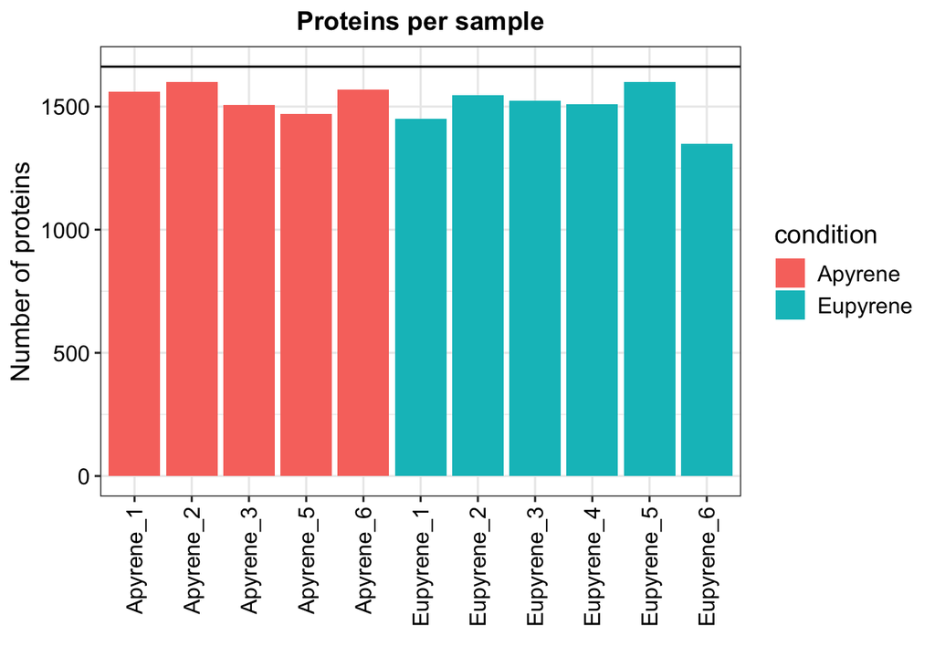

```r
plot_numbers(pieris.filt)
```

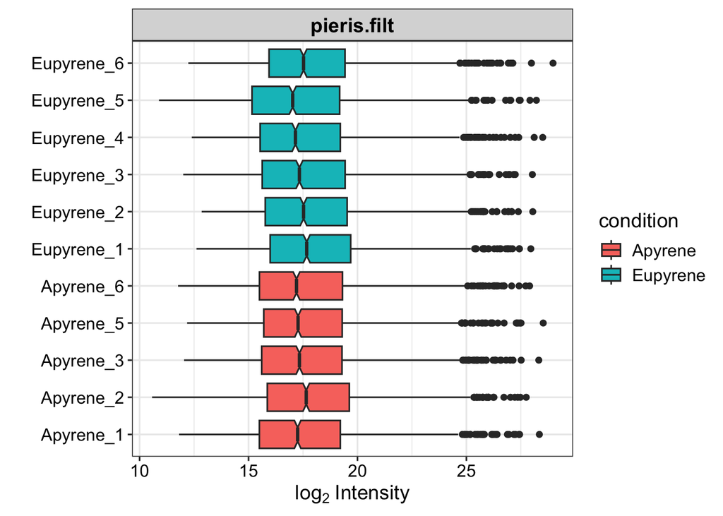

```r
plot_normalization(pieris.filt)
```

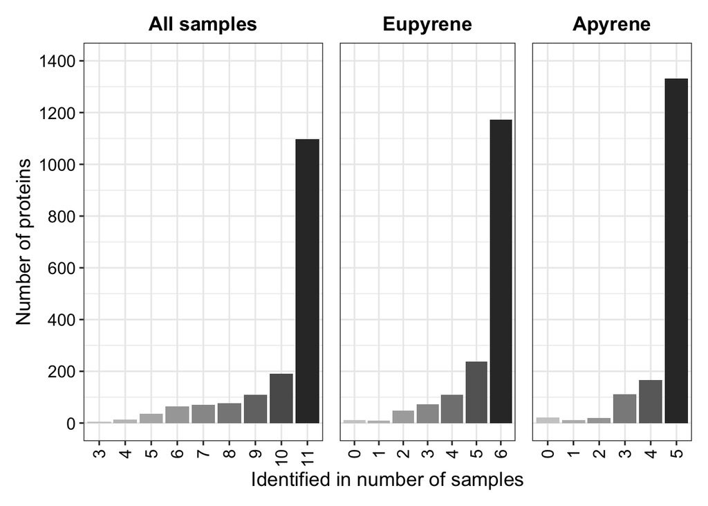

```r
yLims <- c(0,1400)
all.freq <- plot_frequency(pieris.filt) +
  labs(title = "All samples") +
  scale_y_continuous(breaks = c(seq(0, 1500, 200)), limits = yLims)

apy.freq <- plot_frequency(pieris.filt[,pieris.filt$condition == "Apyrene"]) +
  labs(title = "Apyrene") +
  scale_y_continuous(breaks = c(seq(0, 1500, 200)), limits = yLims)


eup.freq <- plot_frequency(pieris.filt[,pieris.filt$condition == "Eupyrene"]) +
  labs(title = "Eupyrene") +
  scale_y_continuous(breaks = c(seq(0, 1500, 200)), limits = yLims)



overlaps <- all.freq + eup.freq + apy.freq  + plot_layout(axis_titles = "collect",
                                                         widths = c(3,2.2,2),
                                                         axes = "collect")
print(overlaps)
```

```r
ggsave(filename = "../Results/Overlaps.pdf", plot = overlaps, width = 6, height = 3, scale = 1.3)
```

# Missing Data

## Assess missing data

There are many proteins which have incomplete sets of observations. Roughly a third of the proteins have at least one missing value. And plots of abundances partitioned by missing values clearly shows lower abundance for proteins with missing values, consistent with reduced opportunity for detection.

```r
sum( apply( is.na(assay(pieris.filt)), 1, any ) )
```

```
## [1] 565
```

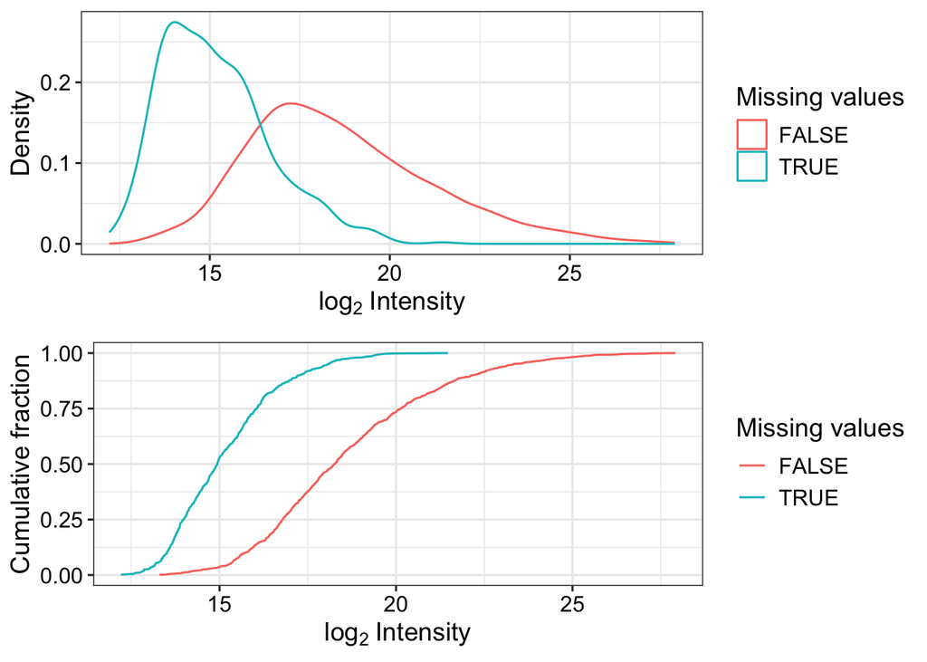

```r
plot_detect(pieris.filt)
```

Now let’s assess which proteins may be missing at random (MAR) versus not (MNAR). We will require 2 or more observations in both morphs to be MAR, and otherwise they will be MNAR, In other words, MNAR will have 1 or 0 observations in one morph, and at least 3 in the other.

```r
obs.required <- 2

rowData(pieris.filt)$mar <- rowData(pieris.filt)$Nobs.apy >= obs.required & rowData(pieris.filt)$Nobs.eup >= obs.required

# subset to only proteins with any missing values, then tabulate MAR/MNAR
table(rowData(pieris.filt[apply( is.na(assay(pieris.filt)), 1, any )])$mar )
```

```
##
## FALSE  TRUE
##    55   510
```

Now we can examine patterns of missing values via heatmap, for MAR and MNAR proteins. Here I’ve hacked the `plot_missval()` function from `DEP`.

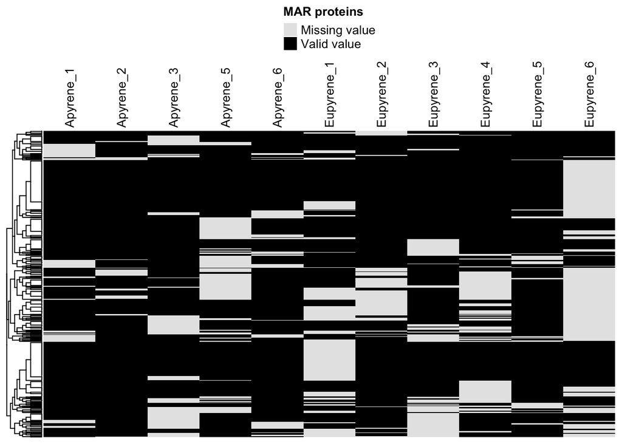

```r
suppressMessages( library(ComplexHeatmap) )

plot_missval.jrw <- function (se, title = "Missing Values Pattern")
{
    assertthat::assert_that(inherits(se, "SummarizedExperiment"))
    se_assay <- assay(se)
    if (!any(is.na(se_assay))) {
        stop("No missing values in '", deparse(substitute(se)),
            "'", call. = FALSE)
    }
    #df <- se_assay %>% data.frame(.)
    df <- as.data.frame(se_assay)
    missval <- df[apply(df, 1, function(x) any(is.na(x))), ]
    missval <- ifelse(is.na(missval), 0, 1)
    ht2 = Heatmap(missval, col = c("grey90", "black"), column_names_side = "top", cluster_columns = F,
        show_row_names = FALSE, show_column_names = TRUE, name = title,
        column_names_gp = gpar(fontsize = 10), heatmap_legend_param = list(at = c(0,
            1), labels = c("Missing value", "Valid value")))
    draw(ht2, heatmap_legend_side = "top")
}

plot_missval.jrw(pieris.filt[rowData(pieris.filt)$mar], title = "MAR proteins")
```

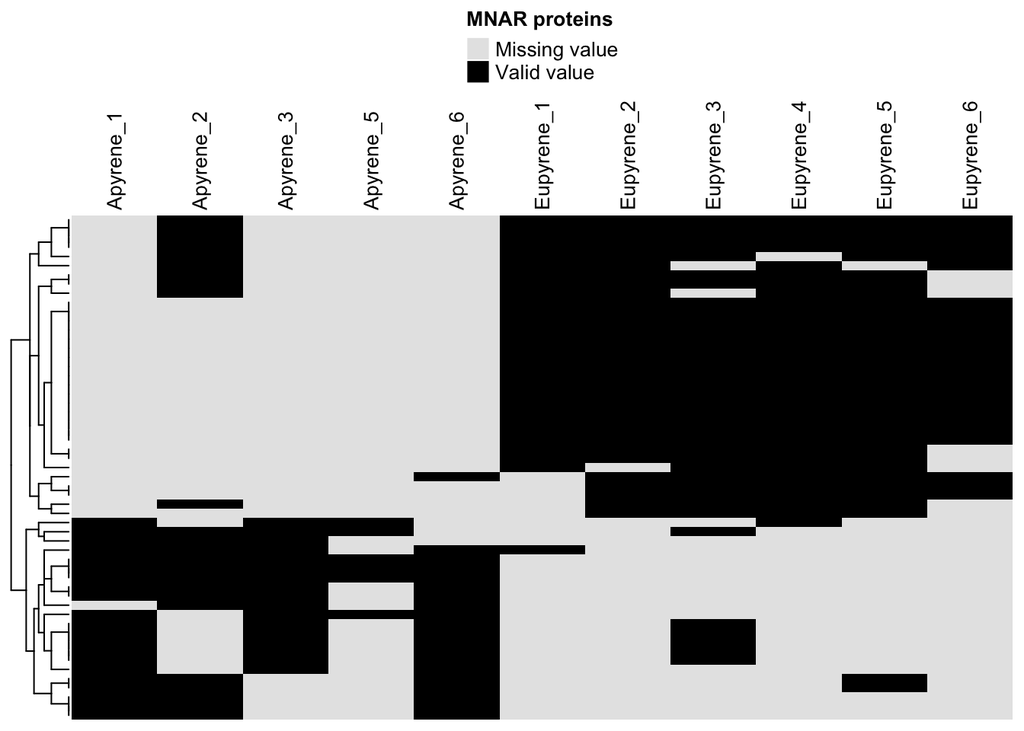

```r
plot_missval.jrw(pieris.filt[!rowData(pieris.filt)$mar], title = "MNAR proteins")
```

```r
## Write out plots for publication
pdf(file = "../Results/MissingVals_Heatmaps.pdf", width = 6, height = 4)

plot_missval.jrw(pieris.filt[rowData(pieris.filt)$mar], title = "MAR proteins")

plot_missval.jrw(pieris.filt[!rowData(pieris.filt)$mar], title = "MNAR proteins")

dev.off()
```

Combine the two heatmaps into a single plot, which will be more useful than the pdf for including as a supplemental figure.

```r
missvalsfile <- "../Results/MissingVals_Heatmaps.jpg"

marPlot <- grid.grabExpr(plot_missval.jrw(pieris.filt[rowData(pieris.filt)$mar], title = "MAR proteins"))

mnarPlot <- grid.grabExpr(plot_missval.jrw(pieris.filt[!rowData(pieris.filt)$mar], title = "MNAR proteins"))

jpeg(filename = missvalsfile, height = 10, width = 8, units = "in", res = 300)
wrap_plots(marPlot, mnarPlot, ncol = 1)
dev.off()
```

## Qualitative Differences

There is a basic expectation, based on precedent from our previous Lep sperm proteomes, that some proteins should be found in only one sperm morph. In this case, we will use a qualitative presence/absence metric to identify these proteins: The protein must be present in four bioreps of one morph, and present 0 or 1 times in the other. Permitting 1 replicate allows for some error due to contamination during sperm separation.

All of these proteins will overlap with the “MNAR” subset later in analyses.

```r
# Find eupyrene specific proteins
rowData(pieris.filt)$specific.eup <- rowData(pieris.filt)$Nobs.eup >= 4 &
  rowData(pieris.filt)$Nobs.apy <= 1
sum(rowData(pieris.filt)$specific.eup)
```

```
## [1] 33
```

```r
# Find apyrene specific proteins
rowData(pieris.filt)$specific.apy <- rowData(pieris.filt)$Nobs.apy >= 4 &
  rowData(pieris.filt)$Nobs.eup <= 1
sum(rowData(pieris.filt)$specific.apy)
```

```
## [1] 8
```

```r
# Select all the morph-specific proteins
specific.se <- pieris.filt[ rowData(pieris.filt)$specific.eup | rowData(pieris.filt)$specific.apy, ]
nrow(specific.se)
```

```
## [1] 41
```

## Imputing missing data: Mixed Approach

At this point, we will impute missing values so as to allow full testing for differential expression. Since we appear to have a mix of MAR with some MNAR proteins, we will apply a mixed approach to imputing. This approach follows the principles and guidance from the [DEP vignette on handling missing values](https://bioconductor.org/packages/release/bioc/vignettes/DEP/inst/doc/MissingValues.html) and also related [MSnbase vignette](https://bioconductor.org/packages/3.14/bioc/vignettes/MSnbase/inst/doc/v01-MSnbase-demo.html#8_Processing_quantitative_data)

We will use the “MinDet” method for MNAR and “MLE” for MAR.

Note that at least the MLE method has a random component to it, as it uses `norm::imp.norm()`, so I will `set.seed()` for reproducibility here.

```r
set.seed(1)
pieris.imp.mle <- impute(se = pieris.filt, fun = "mixed",
                         randna = rowData(pieris.filt)$mar,
                         mar = "MLE", mnar = "MinDet" )
```

```
## Imputing along margin 1 (features/rows).
```

```
## Iterations of EM:
## 1...2...3...4...5...6...7...8...9...10...11...12...
```

```
## Imputing along margin 1 (features/rows).
```

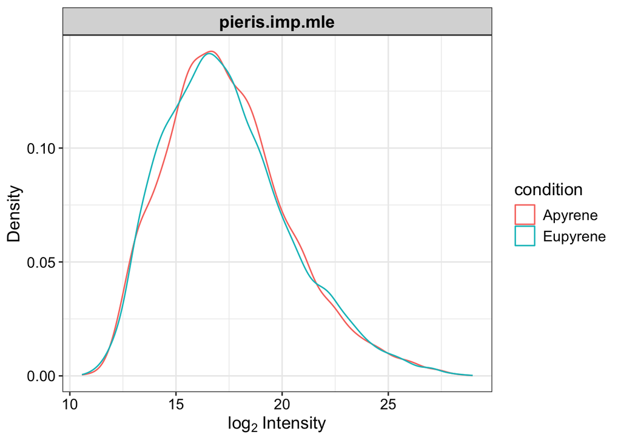

```r
plot_imputation(pieris.imp.mle)
```

## Calculate Mean Abundances

```r
apy_meanAbundance <- pieris.imp.mle[ , pieris.imp.mle$condition == "Apyrene"]
rowData(pieris.imp.mle)$Means.Apy <- rowMeans(assay(apy_meanAbundance))

eupy_meanAbundance <- pieris.imp.mle[ , pieris.imp.mle$condition == "Eupyrene"]
rowData(pieris.imp.mle)$Means.Eupy <- rowMeans(assay(pieris.imp.mle))

rowData(pieris.imp.mle)$Means.All <- rowMeans(assay(pieris.imp.mle)) #Store in col of rowData
```

# Differential Abundance Testing

With imputed data, we are ready to perform differential expression analysis. DEP breaks this into a few steps, so we will compress these into a single wrapper function.

However, the p-value correction for multiple testing employed by DEP is not standard. It uses something called “fdrtool”, which corresponds to some “generalized” approach to multiple testing correction, and not the widely used BH “fdr” approach. The “fdrtool” correction appears extremely conservative, so I will manually add a set of results for BH fdr corrected p-values.

## Applying BH Correction

Require a log fold change of 1.5x to be significant, along with FDR of 0.05. Write a wrapper function to apply these thresholds for significance testing.

```r
do.de.se <- function(my.se, alpha = 0.05, lfc = log2(1.5)) {
  my.se <- test_diff(se = my.se, type = "all")
  my.se <- add_rejections(diff = my.se, alpha = alpha, lfc = lfc)
  rowData(my.se)$Apyrene_vs_Eupyrene_p.bh <- p.adjust(rowData(my.se)$Apyrene_vs_Eupyrene_p.val, method = "BH")
  rowData(my.se)$significant_bh <- ifelse(rowData(my.se)$Apyrene_vs_Eupyrene_p.bh <= alpha & abs(rowData(my.se)$Apyrene_vs_Eupyrene_diff) >= lfc, TRUE, FALSE )
  return(my.se)
}

pieris.imp.mle <- do.de.se(pieris.imp.mle)
```

```
## Tested contrasts: Apyrene_vs_Eupyrene
```

## Plotting Significant BH Results

Here we can plot the relationship between conventional BH type FDR, and `DEP`’s p-value adjustments, which are much more conservative!

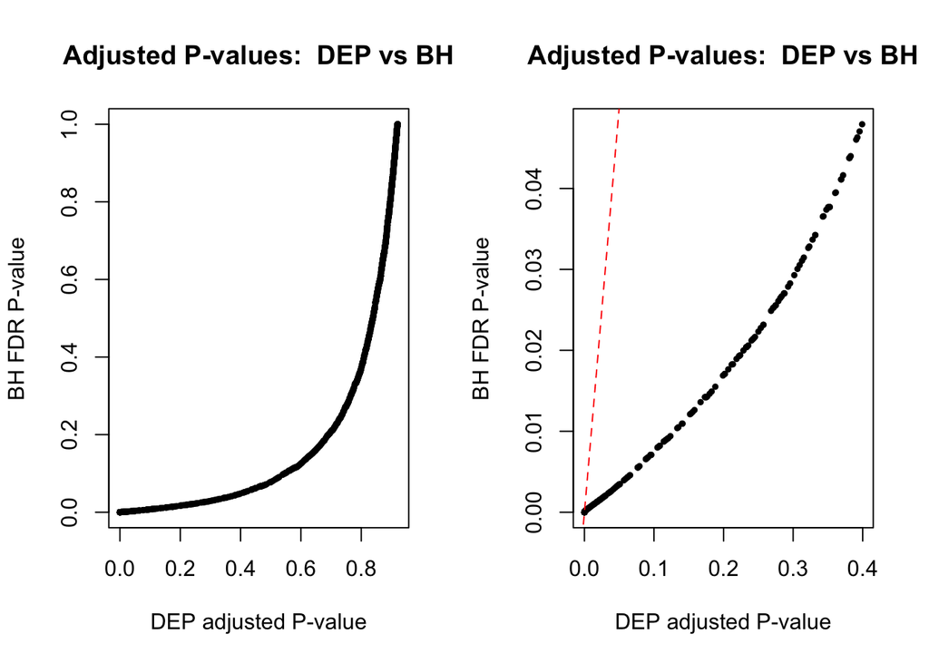

```r
par(mfrow=c(1,2))
plot(x = rowData(pieris.imp.mle)$Apyrene_vs_Eupyrene_p.adj,
     y=rowData(pieris.imp.mle)$Apyrene_vs_Eupyrene_p.bh,
     xlab = "DEP adjusted P-value", ylab = "BH FDR P-value",
     main = "Adjusted P-values:  DEP vs BH", pch = 19, cex = 0.5)


bh.signif <- rowData(pieris.imp.mle)$Apyrene_vs_Eupyrene_p.bh < 0.05
plot(x = rowData(pieris.imp.mle)$Apyrene_vs_Eupyrene_p.adj[bh.signif],
     y = rowData(pieris.imp.mle)$Apyrene_vs_Eupyrene_p.bh[bh.signif],
     xlab = "DEP adjusted P-value", ylab = "BH FDR P-value",
     main = "Adjusted P-values:  DEP vs BH", pch = 19, cex = 0.5)
abline(a = 0, b = 1, lty = 2, col = "red")
```

```r
#BH FDR significance
table(rowData(pieris.imp.mle)$significant_bh, useNA = "always")
```

```
##
## FALSE  TRUE  <NA>
##  1422   240     0
```

# Visualizing results

The visualization tools of `DEP` are “tuned” to use the results from the `fdrtools` package it implements. But we can overwrite the BH results into the “standard” columns used by DEP and get it to plot data based on BH fdr significance.

```r
pieris.hack <- pieris.imp.mle
rowData(pieris.hack)$Apyrene_vs_Eupyrene_p.adj <- rowData(pieris.hack)$Apyrene_vs_Eupyrene_p.bh
rowData(pieris.hack)$Apyrene_vs_Eupyrene_significant <- rowData(pieris.hack)$significant_bh
rowData(pieris.hack)$significant <- rowData(pieris.hack)$significant_bh
```

Now we can generate various plots of the data

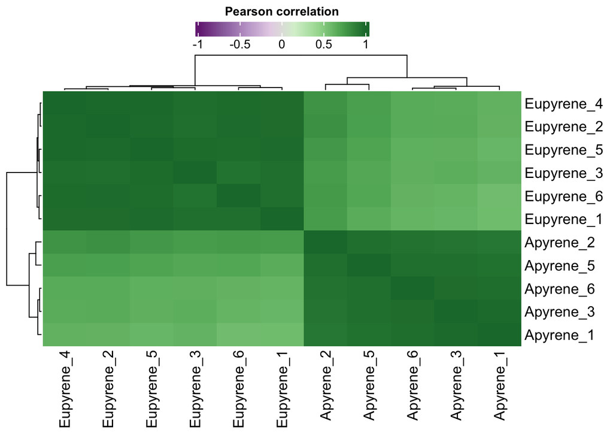

```r
plot_cor(pieris.hack)
```

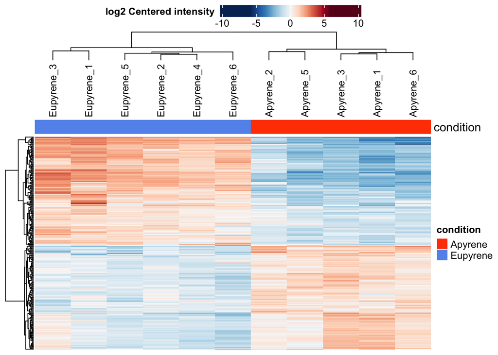

```r
# Plot heatmap of significantly DE proteins
plot_heatmap(pieris.hack, type = "centered", show_row_names = FALSE, indicate = "condition")
```

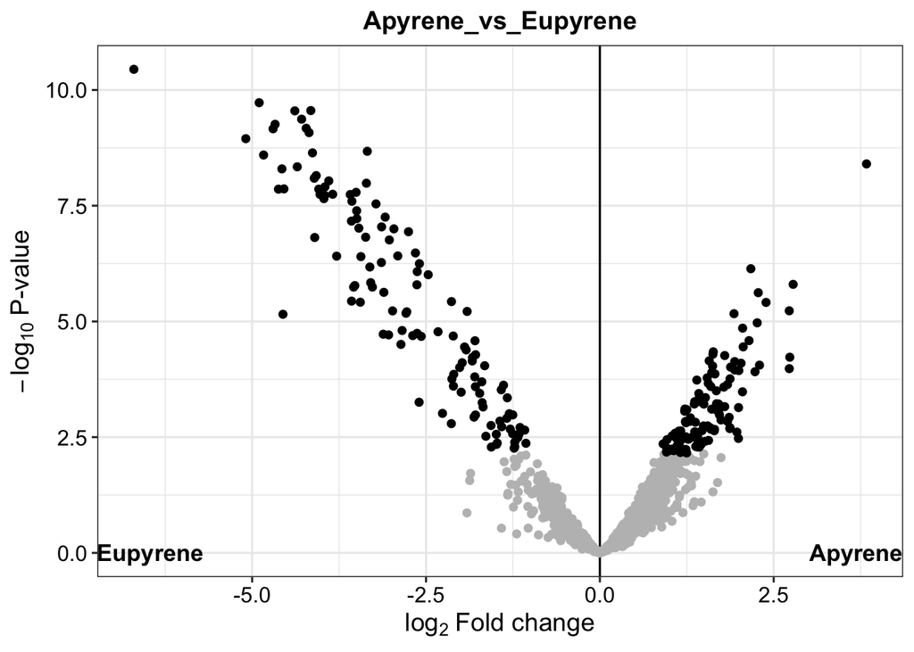

```r
plot_volcano(pieris.hack, contrast = "Apyrene_vs_Eupyrene", add_names = F)
```

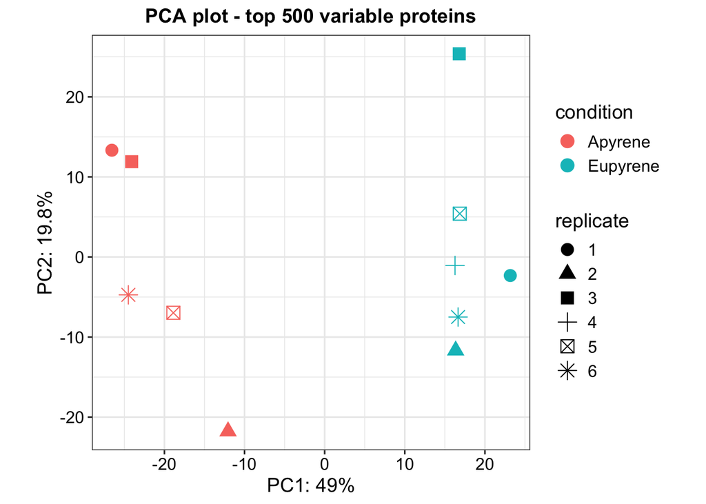

```r
plot_pca(pieris.hack)
```

## Good Volcano

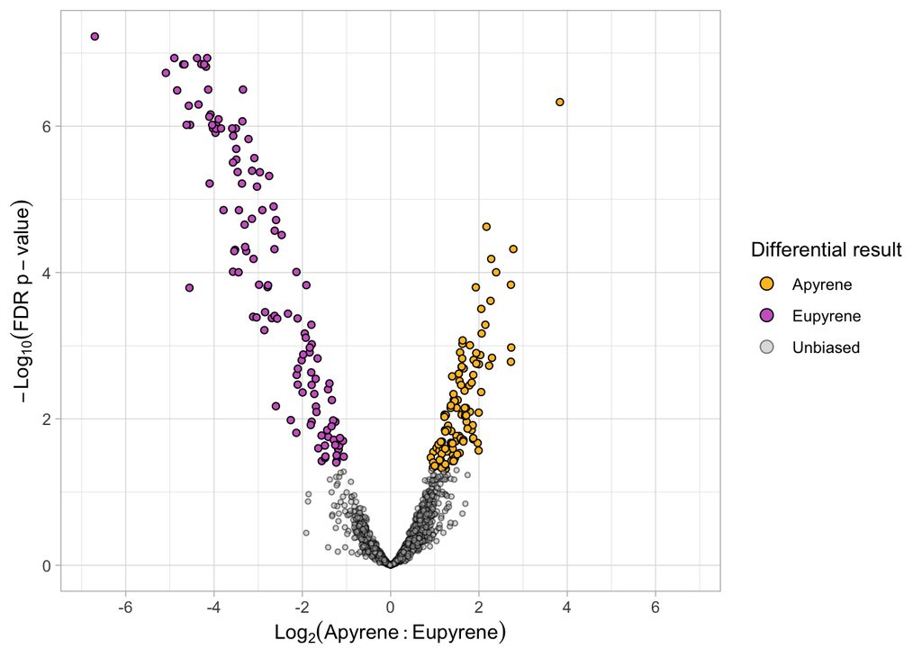

```r
# Extract data from SE object for easy access
volcDat <- rowData(pieris.hack)

# Code results as directionally DE, or unbiased
genetype <- rep("Unbiased", times = nrow(volcDat))
genetype[volcDat$Apyrene_vs_Eupyrene_p.adj < 0.05 &
         volcDat$Apyrene_vs_Eupyrene_diff > 0 ] <- "Apyrene"
genetype[volcDat$Apyrene_vs_Eupyrene_p.adj < 0.05 &
         volcDat$Apyrene_vs_Eupyrene_diff < 0 ] <- "Eupyrene"

cols <- c("Apyrene" = myCols[1], "Eupyrene" = myCols[2], "Unbiased" = "grey")
sizes <- c("Apyrene" = 1.5, "Eupyrene" = 1.5, "Unbiased" = 1)
alphas <- c("Apyrene" = 1, "Eupyrene" = 1, "Unbiased" = 0.5)

legendTitle <- "Differential result"

volcPlot <- ggplot(volcDat, aes(x = Apyrene_vs_Eupyrene_diff,
                    y = -log10(Apyrene_vs_Eupyrene_p.adj),
                    fill = genetype,
                    size = genetype,
                    alpha = genetype)
       ) +
  geom_point(shape = 21, color = "black") +
  scale_fill_manual(legendTitle, values = cols) + # Modify point colour
  scale_size_manual(legendTitle, values = sizes) + # Modify point size
  scale_alpha_manual(legendTitle, values = alphas) +  # Modify point transparency
  theme_light() +
  scale_x_continuous(breaks = c(seq(-10, 10, 2)), limits = c(-6.8,6.8)) +
  ylab(expression(-Log[10](FDR~p-value))) +
  xlab(expression(Log[2](Apyrene:Eupyrene))) +
  guides(fill=guide_legend( override.aes = list(size = 3)) )

print(volcPlot)
```

```r
# PDF
ggsave(plot = volcPlot, filename = "../Results/Volcano_PierisSperm.pdf",
       width = 180, height = 90, units = "mm", scale = 1)
# JPG
ggsave(plot = volcPlot, filename = "../Results/Volcano_PierisSperm.jpg",
       width = 180, height = 90, units = "mm", scale = 1)

ggsave(plot = volcPlot, filename = "../Results/Volcano_PierisSperm_wide.jpg",
       width = 180, height = 70, units = "mm", scale = 1,
       dpi = 300)
```

# Summary & output files

Let’s format data so that it can be easily used with downstream analyses. Add columns that indicate explicitly whether a protein is biased towards apyrene, eupyrene, or is unbiased.

```r
# Create a vector for calling result (apyrene-biased//eupyrene-biased or not)
# Start with all "unbaised". Then assign results based on "qualitative" assessment
master.de <- rep("unbiased", times = nrow(pieris.imp.mle))
master.de[rowData(pieris.imp.mle)$specific.apy] <- "apyrene"
master.de[rowData(pieris.imp.mle)$specific.eup] <- "eupyrene"

# Now add on result based on statistical support
master.de[rowData(pieris.imp.mle)$Apyrene_vs_Eupyrene_diff > 0 &
            rowData(pieris.imp.mle)$significant_bh] <- "apyrene"

master.de[rowData(pieris.imp.mle)$Apyrene_vs_Eupyrene_diff < 0 &
            rowData(pieris.imp.mle)$significant_bh] <- "eupyrene"


rowData(pieris.imp.mle)$master.de <- master.de
```

So in conclusion, we have a total of **1662** proteins detected. And these break down as the following, in terms of DE

```r
table(master.de) |> kable()
```

| master.de | Freq |
| --- | --- |
| apyrene | 125 |
| eupyrene | 150 |
| unbiased | 1387 |

Now how many genes do those proteins belong to?

```r
pierisSpermProtDiffEx <- as.data.frame(rowData(pieris.imp.mle))
apyGenes <- length(unique(pierisSpermProtDiffEx$GeneID[
  pierisSpermProtDiffEx$master.de == "apyrene"] ))
eupGenes <- length(unique(pierisSpermProtDiffEx$GeneID[
  pierisSpermProtDiffEx$master.de == "eupyrene"] ))
unbGenes <- length(unique(pierisSpermProtDiffEx$GeneID[
  pierisSpermProtDiffEx$master.de == "unbiased"] ))

apyGenes
```

```
## [1] 125
```

```r
eupGenes
```

```
## [1] 149
```

```r
unbGenes
```

```
## [1] 1377
```

And among proteins identified qualitatively, how many were *also* identified as DE quantitatively?

```r
# vector indicating qualitative differences
qualDE <- pierisSpermProtDiffEx$specific.apy | pierisSpermProtDiffEx$specific.eup
# vector indicating quantitative DE
quantDE <- pierisSpermProtDiffEx$significant_bh

sum(qualDE) # number of qualDE proteins
```

```
## [1] 41
```

```r
sum(quantDE) # number of quantDE proteins
```

```
## [1] 240
```

```r
sum(qualDE & quantDE) # overlap in qual and quant
```

```
## [1] 6
```

So it appears that only 6 proteins overlap between qualitative and quantitatively assessed “differential” proteins.

## Write output table

Now write out the various files as table and R objects

```r
#Write out a df
pierisSpermProtDiffEx <- as.data.frame(rowData(pieris.imp.mle))

#Save R Objects
save(pierisSpermProtDiffEx , file = "../Results/pierisSpermProtDiffEx.RData")
save(pieris.imp.mle, file = "../Results/pierisImputedMLE.RData")

#Write out to csv
write.csv(pierisSpermProtDiffEx ,"../Results/pierisSpermProtDiffEx.csv", row.names = FALSE)
```

## Extract Sperm Protein Fasta

I need to extract the sperm proteins for subsequent submission to annotation portals (e.g. SignalP, etc). This is a request from reviewers, so I’m adding this step in here, and using a fasta file with the longest protein ORF identified by the gene locus.

```r
allProts <- readAAStringSet(file = "../../Part0_DataCleaning/Results/CleanedProteomeFASTAs/PierisLongestCDS_geneID.fas")

# extract GeneIDs only
allProtNames <- names(allProts)
allGeneID <- sub("\\s.*$", "", allProtNames)

# subset to only Sperm proteins
spermProts <- allProts[ allGeneID %in% pierisSpermProtDiffEx$GeneID ]

writeXStringSet(x = spermProts, filepath = "../Results/pierisSpermProts_GeneID-all.fas")
```

Additionally, some of the resources max out at 1000 submissions, so I need to partition this into two chunks:

```r
chunkSize <- 800

# First chunk
writeXStringSet(x = spermProts[1:chunkSize], filepath = "../Results/pierisSpermProts_GeneID-chunk1.fas")

# Remainder
writeXStringSet(x = spermProts[-(1:chunkSize)], filepath = "../Results/pierisSpermProts_GeneID-chunk2.fas")
```